# Assignment 4

Anuraag Vasal

11/6/2021

```r
library(readr)
library(dplyr)
library(caret)
library(factoextra)
```

```r
library(ggplot2)
library(tidyverse)
library(cowplot)
```

#### Importing Dataset

```r
setwd("C:/Users/anura/Desktop/Machine Learning/Assignment 4")
Pharmaceuticals<- read.csv <- read_csv("Pharmaceuticals.csv")
# Summary
summary(Pharmaceuticals)
```

```
##     Symbol              Name             Market_Cap          Beta
##  Length:21          Length:21          Min.   :  0.41   Min.   :0.1800
##  Class :character   Class :character   1st Qu.:  6.30   1st Qu.:0.3500
##  Mode  :character   Mode  :character   Median : 48.19   Median :0.4600
##                                        Mean   : 57.65   Mean   :0.5257
##                                        3rd Qu.: 73.84   3rd Qu.:0.6500
##                                        Max.   :199.47   Max.   :1.1100
##     PE_Ratio          ROE            ROA        Asset_Turnover    Leverage
##  Min.   : 3.60   Min.   : 3.9   Min.   : 1.40   Min.   :0.3    Min.   :0.0000
##  1st Qu.:18.90   1st Qu.:14.9   1st Qu.: 5.70   1st Qu.:0.6    1st Qu.:0.1600
##  Median :21.50   Median :22.6   Median :11.20   Median :0.6    Median :0.3400
##  Mean   :25.46   Mean   :25.8   Mean   :10.51   Mean   :0.7    Mean   :0.5857
##  3rd Qu.:27.90   3rd Qu.:31.0   3rd Qu.:15.00   3rd Qu.:0.9    3rd Qu.:0.6000
##  Max.   :82.50   Max.   :62.9   Max.   :20.30   Max.   :1.1    Max.   :3.5100
##    Rev_Growth    Net_Profit_Margin Median_Recommendation   Location
##  Min.   :-3.17   Min.   : 2.6      Length:21             Length:21
##  1st Qu.: 6.38   1st Qu.:11.2      Class :character      Class :character
##  Median : 9.37   Median :16.1      Mode  :character      Mode  :character
##  Mean   :13.37   Mean   :15.7
##  3rd Qu.:21.87   3rd Qu.:21.1
##  Max.   :34.21   Max.   :25.5
##    Exchange
##  Length:21
##  Class :character
##  Mode  :character
##
##
##
```

#Data cleaning a)Justify the various choices made in conducting the cluster analysis,such as weights for different variables, the specific clustering algorithm(s) used, the number of clusters formed, and so on.

```r
# Checking NULL values in the dataset.
apply(Pharmaceuticals,2,function(x){any(is.na(x))})
```

```
##                Symbol                  Name            Market_Cap
##                 FALSE                 FALSE                 FALSE
##                  Beta              PE_Ratio                   ROE
##                 FALSE                 FALSE                 FALSE
##                   ROA        Asset_Turnover              Leverage
##                 FALSE                 FALSE                 FALSE
##            Rev_Growth     Net_Profit_Margin Median_Recommendation
##                 FALSE                 FALSE                 FALSE
##              Location              Exchange
##                 FALSE                 FALSE
```

```r
# Using only the numerical variables (1 to 9) for cluster analysis
Pharmaceuticals_1to9 <- Pharmaceuticals %>% select_if(is.numeric)
# Scaling the data frame (z-score).
set.seed(15)
scale_data <- as.data.frame(scale(Pharmaceuticals_1to9))
```

#Estimating the optimal number of clusters.

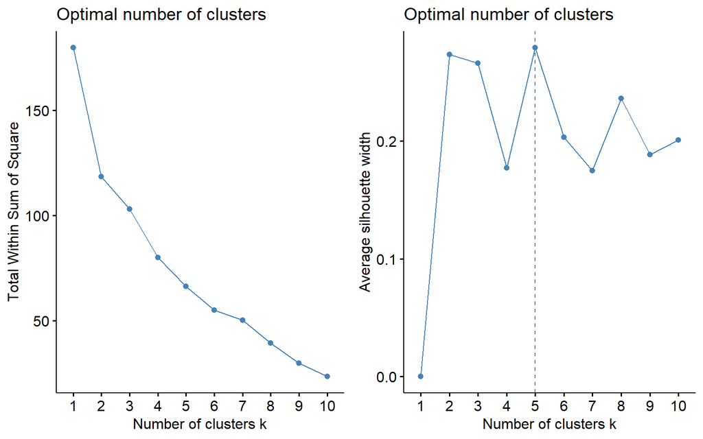

```r
wss1 <- fviz_nbclust(scale_data,FUNcluster = kmeans,method = "wss")
sill1 <- fviz_nbclust(scale_data,FUNcluster = kmeans,method = "silhouette")
plot_grid(wss1, sill1)
```

From Eblow method best K is 2 and From Silhouette Method k is 5.

Finding optimal number of clusters.

Finding IQR

```r
#Finding outliers
outlier_dectecion <- function(x,df = Pharmaceuticals_1to9)
{
  q1 = quantile(df[[x]],0.25) #25th Percentile
  q3 = quantile(df[[x]],0.75) #75th Percentile
  IQR = q3 - q1
  upper_bound = q3 + 1.5 * IQR
  lower_bound = q1 - 1.5 * IQR
  df[(df[x]<lower_bound) | (df[x]>upper_bound),x]
}
out <- vector('list', length(names(Pharmaceuticals_1to9)))
for (i in seq_along(Pharmaceuticals_1to9)){
  x1 <- outlier_dectecion(names(Pharmaceuticals_1to9)[i])
  out[[i]] <- x1
}
names(out) <- names(Pharmaceuticals_1to9)
AfterHandling_outliers <- Pharmaceuticals_1to9 %>%
  filter(Market_Cap != out[[1]], Beta != out[[2]],
         !(PE_Ratio %in% out[[3]]), ROE != out[[4]], !(Leverage %in% out[[7]]))
```

Estimating the optimal number of clusters

Elbow Method and Silhouette Method

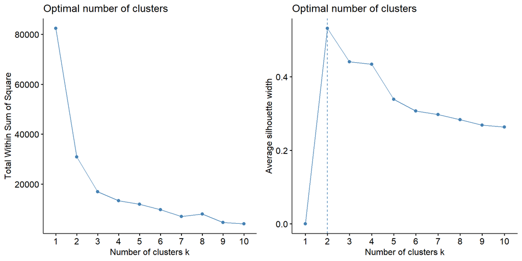

```r
wss2 <- fviz_nbclust(AfterHandling_outliers,FUNcluster = kmeans,method = "wss")
sil2 <- fviz_nbclust(AfterHandling_outliers,FUNcluster = kmeans,method = "silhouette")
plot_grid(wss2, sil2)
```

#For Model building, Considering scaled data without omitting Outliers K = 2

```r
model_K2 <- kmeans(scale_data, centers = 2, nstart = 25)
model_K2
```

```
## K-means clustering with 2 clusters of sizes 11, 10
##
## Cluster means:
##   Market_Cap       Beta   PE_Ratio        ROE        ROA Asset_Turnover
## 1  0.6733825 -0.3586419 -0.2763512  0.6565978  0.8344159      0.4612656
## 2 -0.7407208  0.3945061  0.3039863 -0.7222576 -0.9178575     -0.5073922
##     Leverage Rev_Growth Net_Profit_Margin
## 1 -0.3331068 -0.2902163         0.6823310
## 2  0.3664175  0.3192379        -0.7505641
##
## Clustering vector:
##  [1] 1 2 2 1 2 2 1 2 2 1 1 2 1 2 1 1 1 2 1 2 1
##
## Within cluster sum of squares by cluster:
## [1] 43.30886 75.26049
##  (between_SS / total_SS =  34.1 %)
##
## Available components:
##
## [1] "cluster"      "centers"      "totss"        "withinss"     "tot.withinss"
## [6] "betweenss"    "size"         "iter"         "ifault"
```

K = 3

```r
model_K3 <- kmeans(scale_data, centers = 3, nstart = 25)
model_K3
```

```
## K-means clustering with 3 clusters of sizes 6, 11, 4
##
## Cluster means:
##   Market_Cap       Beta   PE_Ratio        ROE        ROA Asset_Turnover
## 1 -0.8261772  0.4775991 -0.3696184 -0.5631589 -0.8514589     -0.9994088
## 2  0.6733825 -0.3586419 -0.2763512  0.6565978  0.8344159      0.4612656
## 3 -0.6125361  0.2698666  1.3143935 -0.9609057 -1.0174553      0.2306328
##     Leverage Rev_Growth Net_Profit_Margin
## 1  0.8502201  0.9158889        -0.3319956
## 2 -0.3331068 -0.2902163         0.6823310
## 3 -0.3592866 -0.5757385        -1.3784169
##
## Clustering vector:
##  [1] 2 3 3 2 1 3 2 1 1 2 2 1 2 1 2 2 2 3 2 1 2
##
## Within cluster sum of squares by cluster:
## [1] 32.14336 43.30886 20.54199
##  (between_SS / total_SS =  46.7 %)
##
## Available components:
##
## [1] "cluster"      "centers"      "totss"        "withinss"     "tot.withinss"
## [6] "betweenss"    "size"         "iter"         "ifault"
```

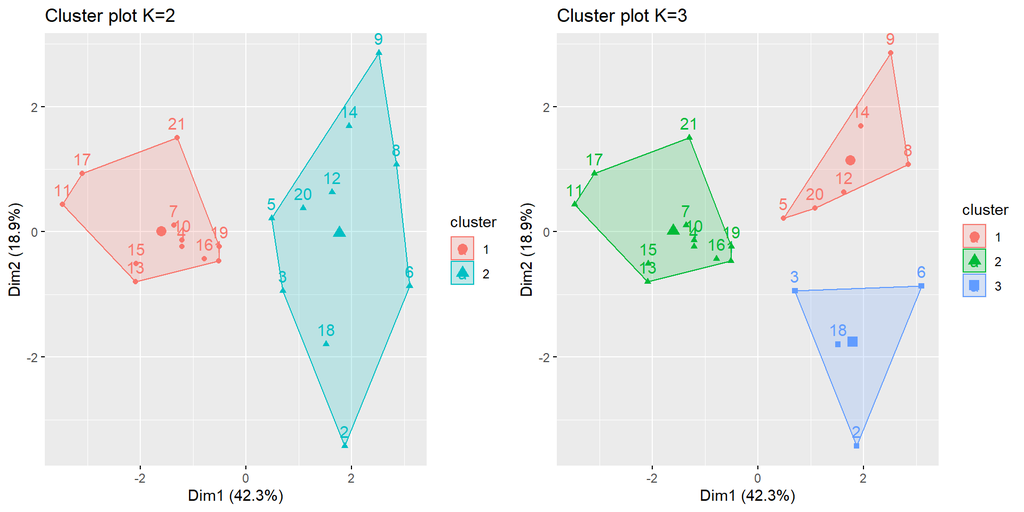

```r
K_2 <- fviz_cluster(model_K2,data = scale_data, main = 'Cluster plot K=2')
K_3 <- fviz_cluster(model_K3,data = scale_data, main = 'Cluster plot K=3')
plot_grid(K_2, K_3)
```

#Considering all the observations, 3 looks like an optimal k.

#Q2: Cluster analysis

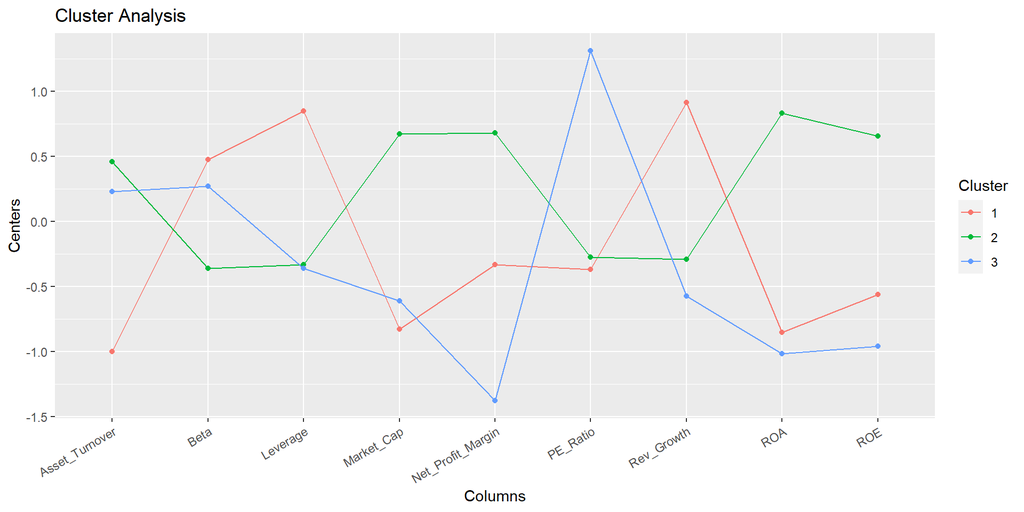

```r
clusters_centers <- data.frame(model_K3$centers) %>%
  rowid_to_column() %>%
  gather('Columns', 'Centers', -1)
ggplot(clusters_centers, aes(x = Columns, y = Centers, color = as.factor(rowid))) +
  geom_line(aes(group = as.factor(rowid))) + geom_point() +
  labs(color = "Cluster", title = 'Cluster Analysis') +
  theme(axis.text.x = element_text(angle = 30, hjust = 1, vjust = 1))
```

From the above graph we can infer that all cluster patterns are different;

#Q3: Applying above Cluster patterns

```r
(Pharmaceuticals_10to12 <-  Pharmaceuticals %>% select(c("Median_Recommendation","Location","Exchange")) %>%
  mutate(cluster_pattern = model_K3$cluster) %>% arrange(desc(cluster_pattern)))
```

```
## # A tibble: 21 x 4
##    Median_Recommendation Location Exchange cluster_pattern
##    <chr>                 <chr>    <chr>              <int>
##  1 Moderate Buy          CANADA   NYSE                   3
##  2 Strong Buy            UK       NYSE                   3
##  3 Hold                  GERMANY  NYSE                   3
##  4 Hold                  US       NYSE                   3
##  5 Moderate Buy          US       NYSE                   2
##  6 Moderate Sell         UK       NYSE                   2
##  7 Moderate Sell         US       NYSE                   2
##  8 Hold                  US       NYSE                   2
##  9 Hold                  UK       NYSE                   2
## 10 Moderate Buy          US       NYSE                   2
## # ... with 11 more rows
```

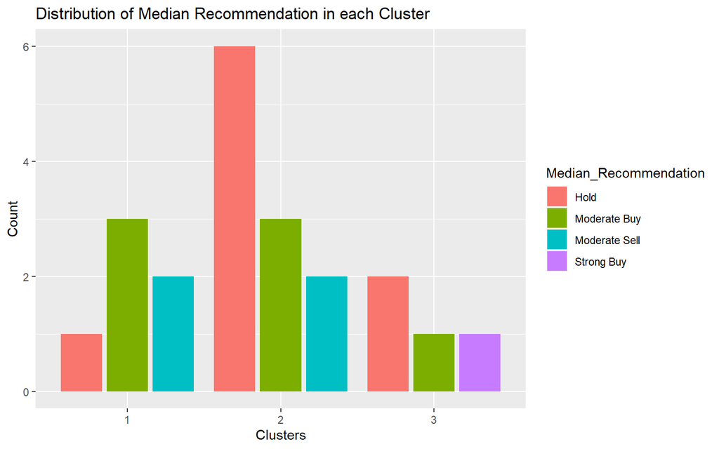

```r
ggplot(Pharmaceuticals_10to12, aes(fill = Median_Recommendation,
x = as.factor(cluster_pattern))) +
  geom_bar(position = 'dodge2') +
labs(x="Clusters", y="Count",
     title = "Distribution of Median Recommendation in each Cluster")
```

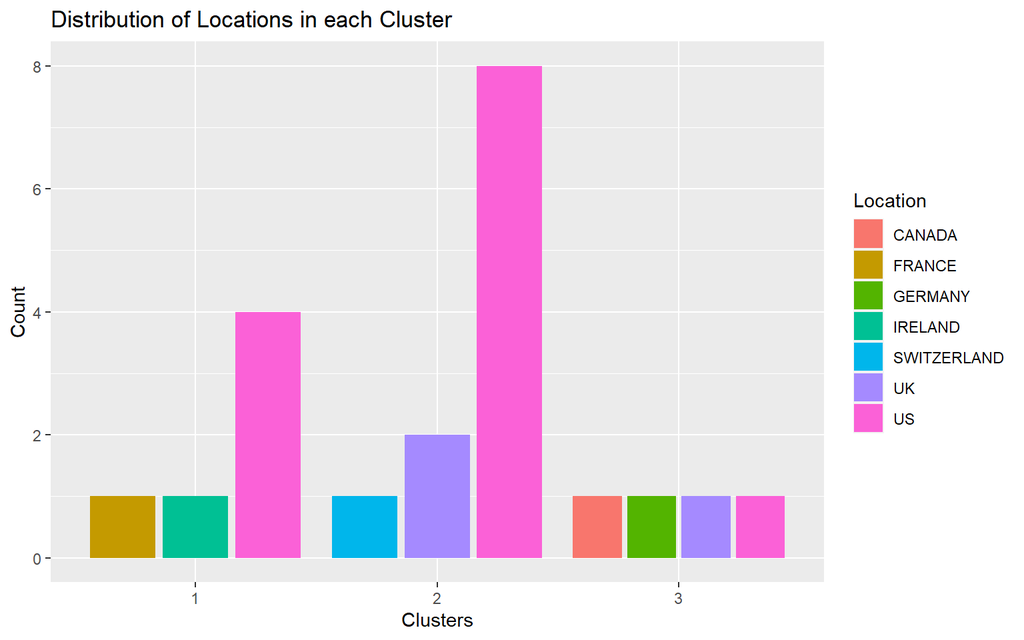

```r
ggplot(Pharmaceuticals_10to12, aes(fill = Location,
x = as.factor(cluster_pattern))) +
  geom_bar(position = 'dodge2') +
labs(x="Clusters", y="Count",
     title = "Distribution of Locations in each Cluster")
```

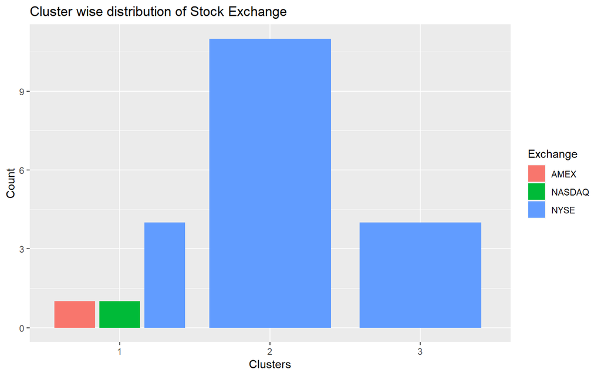

```r
ggplot(Pharmaceuticals_10to12, aes(fill = Exchange,
x = as.factor(cluster_pattern))) +
  geom_bar(position = 'dodge2') +
labs(x="Clusters", y="Count",
     title = "Cluster wise distribution of Stock Exchange")
```

#Q4: Providing an appropriate name for each cluster.

#Small Cap: High PE Ratio.

#Mid Cap: Fast growing with less Market capital and assets.

#Large Cap: High Assets and Market capital.